# CS165 HW1

```python
import numpy as np
import matplotlib.pyplot as plt
```

```python
# Load Data
insertion = np.genfromtxt('insertion.csv', delimiter=',')
merge = np.genfromtxt('merge.csv', delimiter=',')
shell1 = np.genfromtxt('shell1.csv', delimiter=',')
shell2 = np.genfromtxt('shell2.csv', delimiter=',')
shell3 = np.genfromtxt('shell3.csv', delimiter=',')
shell4 = np.genfromtxt('shell4.csv', delimiter=',')
hybrid1 = np.genfromtxt('hybrid1.csv', delimiter=',')
hybrid2 = np.genfromtxt('hybrid2.csv', delimiter=',')
hybrid3 = np.genfromtxt('hybrid3.csv', delimiter=',')
```

```python
# The first tenth lines of the data are for uniform distributed permutations,
# the second then lines are for almost-sorted permutations, and the last ten
# lines are for reverse sorted permuations.Therefore, using these masks to
# obtain these data
uniform_mask = np.arange(0,10)
almost_sorted_mask = np.arange(10, 20)
reverse_sorted_mask = np.arange(20, 30)
```

```python
# Print out one set of data for example
print(insertion[uniform_mask])
```

```
[[1.02400e+03 3.70000e-02]
 [2.04800e+03 3.70000e-02]
 [4.09600e+03 5.80000e-02]
 [8.19200e+03 1.69000e-01]
 [1.63840e+04 5.93000e-01]
 [3.27680e+04 2.02700e+00]
 [6.55360e+04 8.41300e+00]
 [1.31072e+05 3.33690e+01]
 [2.62144e+05 1.31413e+02]
 [5.24288e+05 5.34231e+02]]
```

The first colume indicates the sizes of the input data, which are 2^n where n=10....19. The second colume indicates the running times of the sorting algorithm. These runing times are the results of the average of 5 runs of the sorting algortihm with the input size.

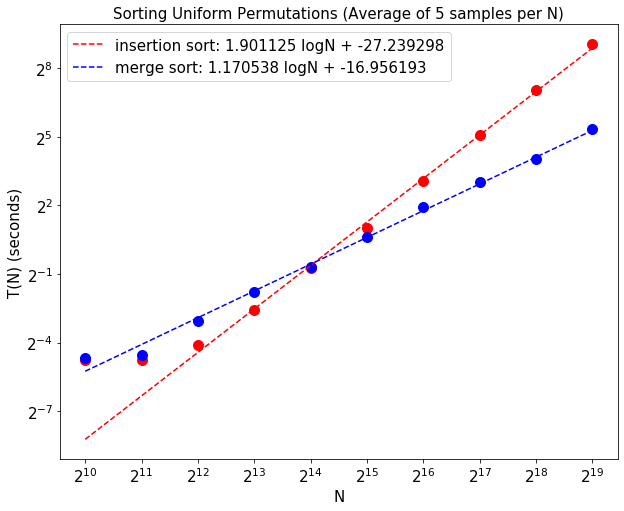

```python
# Plotting Sorting Uniform Permutations (Insertion Sort, Merge Sort)
f, ax = plt.subplots(1,1, figsize=(10,8))


m1, b1 = np.polyfit(np.log2(insertion[uniform_mask][2:,0]), np.log2(insertion[uniform_mask][2:,1]), 1)
m2, b2 = np.polyfit(np.log2(merge[uniform_mask][:,0]), np.log2(merge[uniform_mask][:,1]), 1)


plt.loglog(insertion[uniform_mask][:,0], insertion[uniform_mask][:,1], '.', basex=2, basey=2,
           markersize=20, color='red')
plt.loglog(merge[uniform_mask][:,0], merge[uniform_mask][:,1], '.', basex=2, basey=2,
           markersize=20, color='blue')

plt.loglog(insertion[uniform_mask][:,0], 2**(m1*np.log2(insertion[uniform_mask][:,0])+b1), basex=2, basey=2,
          linestyle='--', label=f'insertion sort: {m1:4f} logN + {b1:4f}', color='red')
plt.loglog(merge[uniform_mask][:,0], 2**(m2*np.log2(merge[uniform_mask][:,0])+b2), basex=2, basey=2,
          linestyle='--', label=f'merge sort: {m2:4f} logN + {b2:4f}', color='blue')

plt.xlabel('N', fontsize=15)
plt.ylabel('T(N) (seconds)', fontsize=15)
plt.xticks(insertion[uniform_mask][:,0], fontsize=15)
plt.yticks(fontsize=15)
plt.title('Sorting Uniform Permutations (Average of 5 samples per N)', fontsize=15)
plt.legend(fontsize=15)
plt.show()
```

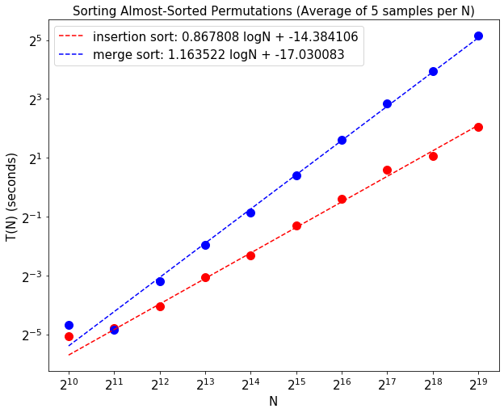

```python
# Plotting Sorting Almost-sorted Permutations (Insertion Sort, Merge Sort)
f, ax = plt.subplots(1,1, figsize=(10,8))


m1, b1 = np.polyfit(np.log2(insertion[almost_sorted_mask][2:,0]), np.log2(insertion[almost_sorted_mask][2:,1]), 1)
m2, b2 = np.polyfit(np.log2(merge[almost_sorted_mask][:,0]), np.log2(merge[almost_sorted_mask][:,1]), 1)


plt.loglog(insertion[almost_sorted_mask][:,0], insertion[almost_sorted_mask][:,1], '.', basex=2, basey=2,
           markersize=20, color='red')
plt.loglog(merge[almost_sorted_mask][:,0], merge[almost_sorted_mask][:,1], '.', basex=2, basey=2,
           markersize=20, color='blue')

plt.loglog(insertion[almost_sorted_mask][:,0], 2**(m1*np.log2(insertion[almost_sorted_mask][:,0])+b1), basex=2, basey=2,
          linestyle='--', label=f'insertion sort: {m1:4f} logN + {b1:4f}', color='red')
plt.loglog(merge[almost_sorted_mask][:,0], 2**(m2*np.log2(merge[almost_sorted_mask][:,0])+b2), basex=2, basey=2,
          linestyle='--', label=f'merge sort: {m2:4f} logN + {b2:4f}', color='blue')

plt.xlabel('N', fontsize=15)
plt.ylabel('T(N) (seconds)', fontsize=15)
plt.xticks(insertion[almost_sorted_mask][:,0], fontsize=15)
plt.yticks(fontsize=15)
plt.title('Sorting Almost-Sorted Permutations (Average of 5 samples per N)', fontsize=15)
plt.legend(fontsize=15)
plt.show()
```

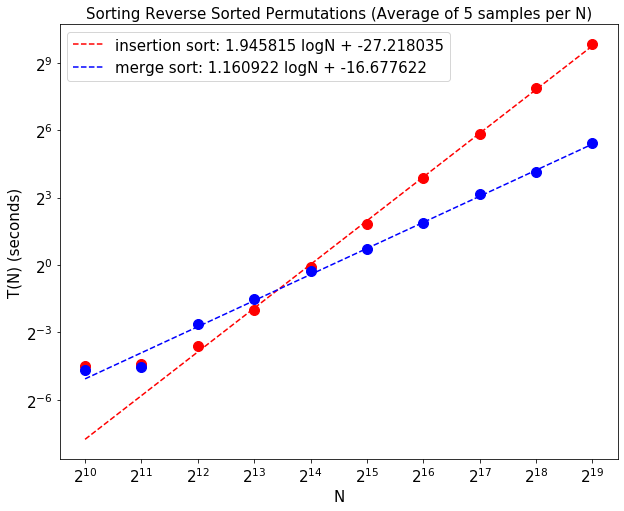

```python
# Plotting Sorting Almost-sorted Permutations (Insertion Sort, Merge Sort)
f, ax = plt.subplots(1,1, figsize=(10,8))


m1, b1 = np.polyfit(np.log2(insertion[reverse_sorted_mask][2:,0]), np.log2(insertion[reverse_sorted_mask][2:,1]), 1)
m2, b2 = np.polyfit(np.log2(merge[reverse_sorted_mask][:,0]), np.log2(merge[reverse_sorted_mask][:,1]), 1)


plt.loglog(insertion[reverse_sorted_mask][:,0], insertion[reverse_sorted_mask][:,1], '.', basex=2, basey=2,
           markersize=20, color='red')
plt.loglog(merge[reverse_sorted_mask][:,0], merge[reverse_sorted_mask][:,1], '.', basex=2, basey=2,
           markersize=20, color='blue')

plt.loglog(insertion[reverse_sorted_mask][:,0], 2**(m1*np.log2(insertion[reverse_sorted_mask][:,0])+b1), basex=2, basey=2,
          linestyle='--', label=f'insertion sort: {m1:4f} logN + {b1:4f}', color='red')
plt.loglog(merge[reverse_sorted_mask][:,0], 2**(m2*np.log2(merge[reverse_sorted_mask][:,0])+b2), basex=2, basey=2,
          linestyle='--', label=f'merge sort: {m2:4f} logN + {b2:4f}', color='blue')

plt.xlabel('N', fontsize=15)
plt.ylabel('T(N) (seconds)', fontsize=15)
plt.xticks(insertion[reverse_sorted_mask][:,0], fontsize=15)
plt.yticks(fontsize=15)
plt.title('Sorting Reverse Sorted Permutations (Average of 5 samples per N)', fontsize=15)
plt.legend(fontsize=15)
plt.show()
```

Comments:  
First of all, I did not use the data points with the size of 2^10 and 2^11 for the best-fit linear regression of insertion sort because when the size of the data is small, the result cannot be fitted with a line. From the plot, we can see that insertion sort will be faster algorithm comparing to merge sort when the input size is relatively small. As the input size goes bigger, merge sort will overperform insertion sort, which means merge sort will be faster than insertion sort for large input size.  
From the slopes of the asymptotic best-fit lines, we can see that with Uniform Permutations(average case) and Reverse Sorted Permutations(worst case), insertion sort has a slope close to 2. This means the running time is growing quadratically with the growing input size, and the average and worst case time complexity of insertion sort are O(N^2). However, with Almost Sorted Permutations, insertion sort has a slope close to 1. This means the running time is growing linearly with the growing input size, and the time complexity of insertion sort in this case is O(N). This is the best case for insertion sort. In this case my insertion sort even overperforms my merge sort.  
For merge sort, we can see that no matter which permutation we are using, the slopes of the asymptotic best-fit lines are always about 1.16 or 1.17. This means the running time of merge sort is always a little bit slower than linear running time which should have a slope of 1. This is reasonable since we knnow that the time complexity of merge sort is O(NlogN). This also concludes that different permutations of the input number have no impact on the running time of merge sort.

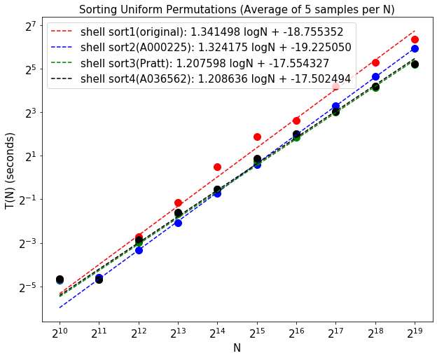

```python
# Plotting Sorting Uniform Permutations (Shell Sort)
f, ax = plt.subplots(1,1, figsize=(10,8))


m1, b1 = np.polyfit(np.log2(shell1[uniform_mask][1:,0]), np.log2(shell1[uniform_mask][1:,1]), 1)
m2, b2 = np.polyfit(np.log2(shell2[uniform_mask][1:,0]), np.log2(shell2[uniform_mask][1:,1]), 1)
m3, b3 = np.polyfit(np.log2(shell3[uniform_mask][1:,0]), np.log2(shell3[uniform_mask][1:,1]), 1)
m4, b4 = np.polyfit(np.log2(shell4[uniform_mask][1:,0]), np.log2(shell4[uniform_mask][1:,1]), 1)


plt.loglog(shell1[uniform_mask][:,0], shell1[uniform_mask][:,1], '.', basex=2, basey=2,
           markersize=20, color='red')
plt.loglog(shell2[uniform_mask][:,0], shell2[uniform_mask][:,1], '.', basex=2, basey=2,
           markersize=20, color='blue')
plt.loglog(shell3[uniform_mask][:,0], shell3[uniform_mask][:,1], '.', basex=2, basey=2,
           markersize=20, color='green')
plt.loglog(shell4[uniform_mask][:,0], shell4[uniform_mask][:,1], '.', basex=2, basey=2,
           markersize=20, color='black')

plt.loglog(shell1[uniform_mask][:,0], 2**(m1*np.log2(shell1[uniform_mask][:,0])+b1), basex=2, basey=2,
          linestyle='--', label=f'shell sort1(original): {m1:4f} logN + {b1:4f}', color='red')
plt.loglog(shell2[uniform_mask][:,0], 2**(m2*np.log2(shell2[uniform_mask][:,0])+b2), basex=2, basey=2,
          linestyle='--', label=f'shell sort2(A000225): {m2:4f} logN + {b2:4f}', color='blue')
plt.loglog(shell3[uniform_mask][:,0], 2**(m3*np.log2(shell3[uniform_mask][:,0])+b3), basex=2, basey=2,
          linestyle='--', label=f'shell sort3(Pratt): {m3:4f} logN + {b3:4f}', color='green')
plt.loglog(shell4[uniform_mask][:,0], 2**(m4*np.log2(shell4[uniform_mask][:,0])+b4), basex=2, basey=2,
          linestyle='--', label=f'shell sort4(A036562): {m4:4f} logN + {b4:4f}', color='black')

plt.xlabel('N', fontsize=15)
plt.ylabel('T(N) (seconds)', fontsize=15)
plt.xticks(shell1[uniform_mask][:,0], fontsize=15)
plt.yticks(fontsize=15)
plt.title('Sorting Uniform Permutations (Average of 5 samples per N)', fontsize=15)
plt.legend(fontsize=15)
plt.show()
```

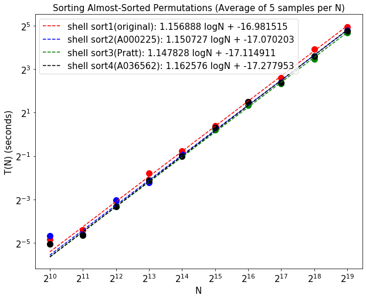

```python
# Plotting Sorting Almost-sorted Permutations (Shell Sort)
f, ax = plt.subplots(1,1, figsize=(10,8))


m1, b1 = np.polyfit(np.log2(shell1[almost_sorted_mask][1:,0]), np.log2(shell1[almost_sorted_mask][1:,1]), 1)
m2, b2 = np.polyfit(np.log2(shell2[almost_sorted_mask][1:,0]), np.log2(shell2[almost_sorted_mask][1:,1]), 1)
m3, b3 = np.polyfit(np.log2(shell3[almost_sorted_mask][1:,0]), np.log2(shell3[almost_sorted_mask][1:,1]), 1)
m4, b4 = np.polyfit(np.log2(shell4[almost_sorted_mask][1:,0]), np.log2(shell4[almost_sorted_mask][1:,1]), 1)


plt.loglog(shell1[almost_sorted_mask][:,0], shell1[almost_sorted_mask][:,1], '.', basex=2, basey=2,
           markersize=20, color='red')
plt.loglog(shell2[almost_sorted_mask][:,0], shell2[almost_sorted_mask][:,1], '.', basex=2, basey=2,
           markersize=20, color='blue')
plt.loglog(shell3[almost_sorted_mask][:,0], shell3[almost_sorted_mask][:,1], '.', basex=2, basey=2,
           markersize=20, color='green')
plt.loglog(shell4[almost_sorted_mask][:,0], shell4[almost_sorted_mask][:,1], '.', basex=2, basey=2,
           markersize=20, color='black')

plt.loglog(shell1[almost_sorted_mask][:,0], 2**(m1*np.log2(shell1[almost_sorted_mask][:,0])+b1),
           basex=2, basey=2, linestyle='--', label=f'shell sort1(original): {m1:4f} logN + {b1:4f}', color='red')
plt.loglog(shell2[almost_sorted_mask][:,0], 2**(m2*np.log2(shell2[almost_sorted_mask][:,0])+b2),
           basex=2, basey=2, linestyle='--', label=f'shell sort2(A000225): {m2:4f} logN + {b2:4f}', color='blue')
plt.loglog(shell3[almost_sorted_mask][:,0], 2**(m3*np.log2(shell3[almost_sorted_mask][:,0])+b3),
           basex=2, basey=2, linestyle='--', label=f'shell sort3(Pratt): {m3:4f} logN + {b3:4f}', color='green')
plt.loglog(shell4[almost_sorted_mask][:,0], 2**(m4*np.log2(shell4[almost_sorted_mask][:,0])+b4),
           basex=2, basey=2, linestyle='--', label=f'shell sort4(A036562): {m4:4f} logN + {b4:4f}', color='black')

plt.xlabel('N', fontsize=15)
plt.ylabel('T(N) (seconds)', fontsize=15)
plt.xticks(shell1[uniform_mask][:,0], fontsize=15)
plt.yticks(fontsize=15)
plt.title('Sorting Almost-Sorted Permutations (Average of 5 samples per N)', fontsize=15)
plt.legend(fontsize=15)
plt.show()
```